# Reproducible analysis and publication tables and figure for the BMT age and ISS correspondence

Andrew J. Portuguese, Dianna S. Howard, Rahul Banerjee

October 05, 2026

# 1 Purpose and use

This report generates Main Table 1, Supplementary Tables 1–6, and Supplementary Figure 1 for the BMT age-and-ISS correspondence, with expandable code for each display.

The default render reruns the analysis using independently obtained [CIBMTR P-5544/MM19-01 data](https://cibmtr.org/CIBMTR/Resources/Publicly-Available-Datasets).

# 2 Shared analysis code

The following sections expose the code that prepares the cohort and computes the results. Publication-specific assembly and display code appears beside each table or figure.

## 2.1 Data preparation and descriptive summaries

**Show shared generating code**

```r
# ---- analysis-constants ----
recode_factor <- function(x, values, labels) factor(x, levels = values, labels = labels)
age_labels <- c('<65', '\u226565')
age_colors <- setNames(c('#0072B2', '#D55E00'), age_labels)
# ---- cohort-and-endpoints ----
# Recoding is matched to the established public analysis; unknown values remain missing.
raw <- read_sas(source_file)
stopifnot(nrow(raw) == 1135L, !anyDuplicated(raw$dcrid), !anyNA(raw$age))
data <- raw |>
  mutate(age_group = factor(ifelse(age < 65, age_labels[1], age_labels[2]), levels = age_labels),
         ISS = recode_factor(iss, 1:3, c('I', 'II', 'III')),
         sex_f = recode_factor(sex, 1:2, c('Male', 'Female')),
         race_f = recode_factor(racegp, c(1, 2, 88), c('White', 'Black or African American', 'Other')),
         kps_f = recode_factor(kpr, 1:2, c('90\u2013100', '<90')),
         hctci_f = factor(case_when(adjhctci == 0 ~ '0', adjhctci %in% 1:2 ~ '1\u20132',
                                   adjhctci %in% 3:5 ~ '\u22653'), levels = c('0', '1\u20132', '\u22653')),
         cyto_f = recode_factor(cytonomod, c(0, 1, 2), c('Standard risk', 'Standard risk', 'High risk')),
         subtype_f = recode_factor(immunogp, 1:4, c('IgG', 'IgA', 'Light chain', 'Nonsecretory/other')),
         induction_f = recode_factor(chemo, 2:3, c('VRD', 'VCD')),
         egfr_f = recode_factor(GFRgpmod, 1:2, c('\u226560', '<60')),
         egfr_dx_f = recode_factor(GFRdxgpmod, 1:2, c('\u226560', '<60')),
         response_f = recode_factor(myestaprgp, 1:3, c('sCR/CR', 'VGPR', 'PR')),
         melphalan_f = recode_factor(lpamgp, 1:2, c('140', '200')),
         maintenance_f = recode_factor(planrxhimod, 0:1, c('No', 'Yes')),
         os_ok = is.finite(intxsurv) & intxsurv >= 0 & dead %in% 0:1,
         pfs_ok = is.finite(intxrel) & intxrel >= 0 & dfs %in% 0:1,
         os_available_f = factor(ifelse(os_ok, 'Available', 'Unavailable'), levels = c('Available', 'Unavailable')),
         pfs_available_f = factor(ifelse(pfs_ok, 'Available', 'Unavailable'), levels = c('Available', 'Unavailable')),
         os_event_f = recode_factor(dead, 0:1, c('No death', 'Death')),
         pfs_event_f = recode_factor(dfs, 0:1, c('No progression/death', 'Progression/death')))
data$cyto_f <- factor(as.character(data$cyto_f), levels = c('Standard risk', 'High risk'))
analytic <- data |> filter(!is.na(ISS), is.finite(age))
adjustments <- c('sex_f', 'kps_f', 'hctci_f', 'cyto_f', 'induction_f', 'egfr_f')
main_vars <- c('age_group', 'ISS', adjustments)
extra_vars <- c('response_f', 'melphalan_f')
analytic$main_complete <- complete.cases(analytic[, c(main_vars, 'dccn')])
analytic$expanded_complete <- complete.cases(analytic[, c(main_vars, extra_vars, 'dccn')])
endpoints <- list(OS = list(time = 'intxsurv', event = 'dead', ok = 'os_ok'),
                  PFS = list(time = 'intxrel', event = 'dfs', ok = 'pfs_ok'))
endpoint_data <- lapply(endpoints, function(e) analytic |> filter(.data[[e$ok]]))
model_data <- lapply(endpoint_data, function(d) d |> filter(main_complete))
expanded_data <- lapply(endpoint_data, function(d) d |> filter(expanded_complete))
counts <- analytic |> count(ISS, age_group, name = 'n')
write_table(counts, 'age_iss_counts')
flow <- data.frame(step = c('Source cohort', 'Missing ISS excluded', 'Known-ISS analytic cohort',
                            'OS endpoint eligible', 'OS primary complete cases', 'PFS endpoint unavailable',
                            'PFS endpoint eligible', 'PFS primary complete cases'),
                   n = c(nrow(raw), sum(is.na(data$ISS)), nrow(analytic), nrow(endpoint_data$OS),
                         nrow(model_data$OS), sum(!analytic$pfs_ok), nrow(endpoint_data$PFS), nrow(model_data$PFS)))
write_table(flow, 'cohort_flow')
stopifnot(nrow(analytic) == 940L, sum(analytic$age_group == age_labels[1]) == 656L,
          sum(analytic$age_group == age_labels[2]) == 284L,
          all(as.integer(table(analytic$ISS[analytic$age_group == age_labels[1]])) == c(242L, 259L, 155L)),
          all(as.integer(table(analytic$ISS[analytic$age_group == age_labels[2]])) == c(103L, 102L, 79L)),
          nrow(endpoint_data$OS) == 940L, nrow(endpoint_data$PFS) == 936L,
          nrow(model_data$OS) == 896L, nrow(model_data$PFS) == 892L,
          sum(endpoint_data$OS$dead) == 120L, sum(endpoint_data$PFS$dfs) == 314L,
          sum(model_data$OS$dead) == 111L, sum(model_data$PFS$dfs) == 292L)
pass('Source unique IDs and all established cohort/age/stage/endpoint/model counts reproduced.')
# ---- descriptive-summaries ----
# Aggregate descriptive tables, with nonmissing denominators and explicit missing rows.
descriptive_vars <- c('age', 'sex_f', 'race_f', 'kps_f', 'hctci_f', 'cyto_f', 'subtype_f',
                      'induction_f', 'egfr_dx_f', 'egfr_f', 'response_f', 'melphalan_f', 'maintenance_f',
                      'os_available_f', 'pfs_available_f', 'os_event_f', 'pfs_event_f')
describe <- function(d, group_cols, vars) {
  keys <- apply(as.data.frame(lapply(d[, group_cols, drop = FALSE], as.character)), 1, paste, collapse = ' | ')
  rows <- list()
  for (g in unique(keys)) {
    sub <- d[keys == g, , drop = FALSE]
    for (v in vars) {
      x <- sub[[v]]; nonmiss <- sum(!is.na(x)); missing <- sum(is.na(x))
      if (v == 'age') {
        q <- quantile(x, c(.25, .5, .75), na.rm = TRUE, names = FALSE)
        rows[[length(rows) + 1L]] <- data.frame(group = g, variable = v, level = 'Continuous',
          group_n = nrow(sub), nonmissing_n = nonmiss, n = nonmiss, percent = NA_real_,
          median = q[2], q1 = q[1], q3 = q[3], minimum = min(x, na.rm = TRUE), maximum = max(x, na.rm = TRUE))
      } else {
        for (lev in levels(x)) {
          nn <- sum(as.character(x) == lev, na.rm = TRUE)
          rows[[length(rows) + 1L]] <- data.frame(group = g, variable = v, level = lev,
            group_n = nrow(sub), nonmissing_n = nonmiss, n = nn,
            percent = if (nonmiss) 100 * nn / nonmiss else NA_real_, median = NA_real_, q1 = NA_real_,
            q3 = NA_real_, minimum = NA_real_, maximum = NA_real_)
        }
      }
      rows[[length(rows) + 1L]] <- data.frame(group = g, variable = v, level = 'Missing',
        group_n = nrow(sub), nonmissing_n = nonmiss, n = missing, percent = 100 * missing / nrow(sub),
        median = NA_real_, q1 = NA_real_, q3 = NA_real_, minimum = NA_real_, maximum = NA_real_)
    }
  }
  bind_rows(rows)
}
write_table(describe(analytic, 'age_group', c('age', 'ISS', setdiff(descriptive_vars, 'age'))), 'baseline_by_age')
write_table(describe(analytic, c('ISS', 'age_group'), descriptive_vars), 'baseline_by_age_and_iss')
data$iss_observed <- ifelse(is.na(data$ISS), 'Missing ISS', 'Known ISS')
write_table(describe(data, 'iss_observed', descriptive_vars), 'known_vs_missing_iss')
write_table(describe(data, c('iss_observed', 'age_group'), descriptive_vars), 'known_vs_missing_iss_by_age')
inclusion_tables <- list(); missing_reason_rows <- list()
for (ep in names(endpoints)) {
  d <- analytic
  d$model_inclusion <- ifelse(!d[[endpoints[[ep]]$ok]], 'Endpoint unavailable',
                             ifelse(d$main_complete, 'Included in primary model', 'Covariate incomplete'))
  d$endpoint <- ep
  inclusion_tables[[ep]] <- describe(d, c('endpoint', 'model_inclusion'), c('age', 'ISS', setdiff(descriptive_vars, 'age')))
  eligible <- endpoint_data[[ep]]
  for (v in c(main_vars, extra_vars, 'dccn')) {
    missing_reason_rows[[length(missing_reason_rows) + 1L]] <- data.frame(endpoint = ep, variable = v,
      eligible_n = nrow(eligible), missing_n = sum(is.na(eligible[[v]])))
  }
}
write_table(bind_rows(inclusion_tables), 'primary_model_included_vs_excluded')
write_table(bind_rows(missing_reason_rows), 'overlapping_covariate_missingness')
# Compact display-ready aggregate exports support readable supplemental Word tables.
compact_descriptive <- function(table) {
  labels <- unique(table[, c('variable', 'level')]); groups <- unique(table$group)
  labels$label <- ifelse(labels$level == 'Continuous', labels$variable, paste(labels$variable, labels$level, sep = ': '))
  for (g in groups) {
    ss <- table[table$group == g, ]
    val <- character(nrow(labels))
    for (i in seq_len(nrow(labels))) {
      r <- ss[ss$variable == labels$variable[i] & ss$level == labels$level[i], ]
      if (!nrow(r)) { val[i] <- ''; next }
      val[i] <- if (r$level == 'Continuous') sprintf('%.1f [%.1f, %.1f]', r$median, r$q1, r$q3) else if (r$level == 'Missing')
        sprintf('%d', r$n) else sprintf('%d (%.1f%%)', r$n, r$percent)
    }
    labels[[g]] <- val
  }
  labels
}
write_table(compact_descriptive(describe(analytic, c('ISS', 'age_group'), descriptive_vars)), 'supplement_baseline_compact')
write_table(compact_descriptive(describe(data, 'iss_observed', descriptive_vars)), 'supplement_iss_missingness_compact')
for (ep in names(endpoints)) write_table(compact_descriptive(inclusion_tables[[ep]]),
                                       paste0('supplement_model_inclusion_', tolower(ep), '_compact'))
age_range <- data.frame(group = c('Known ISS', 'Known ISS age >=70', 'Known ISS age >=75'),
  n = c(nrow(analytic), sum(analytic$age >= 70), sum(analytic$age >= 75)),
  minimum = c(min(analytic$age), min(analytic$age[analytic$age >= 70]), min(analytic$age[analytic$age >= 75])),
  maximum = c(max(analytic$age), max(analytic$age), max(analytic$age)))
write_table(age_range, 'age_range_and_older_counts')
```

## 2.2 Survival estimates and follow-up

**Show shared generating code**

```r
# ---- kaplan-meier-and-followup ----
# Survival estimates and independent product-limit validation.
manual_km <- function(time, event, tau) {
  s <- 1
  for (t in sort(unique(time[event == 1 & time <= tau]))) s <- s * (1 - sum(time == t & event == 1) / sum(time >= t))
  s
}
survival_rows <- list(); km_checks <- list(); km_curves <- list(); km_censors <- list(); km_risks <- list()
for (ep in names(endpoints)) for (stage in levels(analytic$ISS)) for (ag in age_labels) {
  e <- endpoints[[ep]]; d <- endpoint_data[[ep]] |> filter(ISS == stage, age_group == ag)
  f <- survfit(Surv(d[[e$time]], d[[e$event]]) ~ 1, conf.type = 'log-log')
  z <- summary(f, times = c(12, 24, 36), extend = FALSE)
  stopifnot(length(z$time) == 3L, all(z$n.risk > 0))
  survival_rows[[length(survival_rows) + 1L]] <- data.frame(endpoint = ep, ISS = stage, age_group = ag,
    n = nrow(d), events = sum(d[[e$event]]), month = z$time, survival = z$surv,
    lower = z$lower, upper = z$upper, se = z$std.err, n_risk = z$n.risk)
  independent <- vapply(z$time, function(t) manual_km(d[[e$time]], d[[e$event]], t), numeric(1))
  stopifnot(max(abs(independent - z$surv)) < 1e-12)
  km_checks[[length(km_checks) + 1L]] <- data.frame(endpoint = ep, ISS = stage, age_group = ag,
    month = z$time, package = z$surv, independent = independent, difference = z$surv - independent)
  key <- paste(ep, stage)
  km_curves[[length(km_curves) + 1L]] <- data.frame(endpoint = ep, ISS = stage, age_group = ag,
    time = c(0, f$time), survival = c(1, f$surv), lower = c(1, f$lower), upper = c(1, f$upper))
  km_censors[[length(km_censors) + 1L]] <- data.frame(endpoint = ep, ISS = stage, age_group = ag,
    time = f$time[f$n.censor > 0], survival = f$surv[f$n.censor > 0])
  km_risks[[length(km_risks) + 1L]] <- data.frame(endpoint = ep, ISS = stage, age_group = ag,
    month = c(0, 12, 24, 36), n_risk = vapply(c(0, 12, 24, 36), function(t) sum(d[[e$time]] >= t), integer(1)))
}
survival_estimates <- bind_rows(survival_rows)
write_table(survival_estimates, 'survival_estimates')
write_table(bind_rows(km_checks), 'independent_km_checks')
write_table(bind_rows(km_risks), 'survival_at_risk')
old_estimates <- read.csv(file.path(baseline_dir, 'survival_estimates.csv'))
for (i in seq_len(nrow(survival_estimates))) {
  r <- survival_estimates[i, ]; old <- old_estimates[old_estimates$endpoint == r$endpoint & old_estimates$ISS == r$ISS &
      old_estimates$age == r$age_group & old_estimates$month == r$month, ]
  stopifnot(nrow(old) == 1L, abs(r$survival - old$survival) < 1e-12,
            abs(r$lower - old$lower) < 1e-12, abs(r$upper - old$upper) < 1e-12)
}
pass('All 36 KM estimates/CIs match saved outputs; survival probabilities match an independent product-limit calculation.')
follow_row <- function(d, group) {
  f <- survfit(Surv(intxsurv, 1 - dead) ~ 1, data = d, conf.type = 'log-log')
  st <- summary(f)$table
  med <- unname(st['median'])
  stopifnot(manual_km(d$intxsurv, 1 - d$dead, med) <= .5 + 1e-10,
            manual_km(d$intxsurv, 1 - d$dead, max(d$intxsurv[d$intxsurv < med], 0)) >= .5 - 1e-10)
  data.frame(group = group, n = nrow(d), median = med, lower = unname(st['0.95LCL']), upper = unname(st['0.95UCL']))
}
followup <- bind_rows(follow_row(endpoint_data$OS, 'Overall'),
  lapply(age_labels, function(a) follow_row(endpoint_data$OS |> filter(age_group == a), paste('Age', a))),
  lapply(levels(analytic$ISS), function(s) bind_rows(lapply(age_labels, function(a)
    follow_row(endpoint_data$OS |> filter(ISS == s, age_group == a), paste('ISS', s, '\u00b7 Age', a))))))
write_table(followup, 'reverse_km_followup')
old_followup <- read.csv(file.path(baseline_dir, 'reverse_km_followup.csv'))
stopifnot(max(abs(followup$median - old_followup$median)) < 1e-12,
          max(abs(followup$lower - old_followup$lower)) < 1e-12,
          max(abs(followup$upper - old_followup$upper)) < 1e-12)
pass('All reverse-KM estimates/CIs match saved outputs and independently cross survival 0.5 with event status reversed.')
benchmark_rows <- list()
for (ep in names(endpoints)) for (reg in c(2, 3)) {
  e <- endpoints[[ep]]; d <- data |> filter(chemo == reg, .data[[e$ok]])
  f <- survfit(Surv(d[[e$time]], d[[e$event]]) ~ 1)
  obs <- if (ep == 'PFS') unname(summary(f)$table['median']) else summary(f, times = 60)$surv
  target <- if (ep == 'PFS') ifelse(reg == 2, 44.6, 34.1) else ifelse(reg == 2, .79, .60)
  ok <- abs(obs - target) < ifelse(ep == 'PFS', .1, .01)
  stopifnot(ok)
  benchmark_rows[[length(benchmark_rows) + 1L]] <- data.frame(endpoint = ep, regimen = ifelse(reg == 2, 'VRD', 'VCD'),
    metric = ifelse(ep == 'PFS', 'Median PFS months', '5-year OS probability'), observed = obs, published = target, pass = ok)
}
write_table(bind_rows(benchmark_rows), 'published_benchmarks')
pass('Published source-study regimen-level PFS medians and 5-year OS benchmarks reproduced.')
```

## 2.3 Adjusted models and sensitivity comparisons

**Show shared generating code**

```r
# ---- cox-models-and-age-stage-contrasts ----
# Six separate within-ISS models are primary; pooled age x ISS models are sensitivity analyses.
# Response and melphalan sensitivity uses six augmented within-stage fits on identical patients.
fits <- list(); fit_data <- list(); model_rows <- list(); coef_rows <- list(); covariance_rows <- list()
formula_for <- function(e, extra = character(), stage_model = FALSE) {
  rhs <- c(if (stage_model) 'age_group' else 'age_group * ISS', adjustments, extra)
  as.formula(paste0('Surv(', e$time, ',', e$event, ') ~ ', paste(rhs, collapse = ' + ')))
}
register_fit <- function(ep, kind, d, form, stage = 'All') {
  label <- paste(ep, kind, stage, sep = '__')
  fit <- withCallingHandlers(coxph(form, data = d, cluster = dccn, ties = 'efron', x = TRUE, model = TRUE),
                            warning = function(w) record_warning(w, label))
  b <- coef(fit); V <- vcov(fit)
  stopifnot(all(is.finite(b)), all(is.finite(V)), all(diag(V) > 0),
            identical(rownames(V), names(b)), identical(colnames(V), names(b)),
            qr(V)$rank == length(b), fit$n == nrow(d))
  fits[[label]] <<- fit; fit_data[[label]] <<- d
  e <- endpoints[[ep]]
  model_rows[[length(model_rows) + 1L]] <<- data.frame(endpoint = ep, model = kind, stage = stage,
    n = nrow(d), events = sum(d[[e$event]]), centers = length(unique(d$dccn)),
    coefficients = length(b), events_per_coefficient = sum(d[[e$event]]) / length(b),
    iterations = fit$iter, covariance_rank = qr(V)$rank, finite_coefficients = all(is.finite(b)))
  for (s in levels(analytic$ISS)) if (any(d$ISS == s)) {
    sub <- d[d$ISS == s, ]
    model_rows[[length(model_rows) + 1L]] <<- data.frame(endpoint = ep, model = paste(kind, 'stage population'),
      stage = s, n = nrow(sub), events = sum(sub[[e$event]]), centers = length(unique(sub$dccn)),
      coefficients = NA_integer_, events_per_coefficient = NA_real_, iterations = NA_integer_,
      covariance_rank = NA_integer_, finite_coefficients = TRUE)
  }
  coef_rows[[length(coef_rows) + 1L]] <<- data.frame(endpoint = ep, model = kind, stage = stage,
    coefficient = names(b), beta = unname(b), robust_se = sqrt(diag(V)), hr = exp(unname(b)),
    lower = exp(unname(b) - 1.96 * sqrt(diag(V))), upper = exp(unname(b) + 1.96 * sqrt(diag(V))),
    p = 2 * pnorm(-abs(unname(b) / sqrt(diag(V)))))
  vv <- as.data.frame(as.table(V), stringsAsFactors = FALSE)
  names(vv) <- c('coefficient_row', 'coefficient_col', 'robust_covariance')
  vv$endpoint <- ep; vv$model <- kind; vv$stage <- stage
  covariance_rows[[length(covariance_rows) + 1L]] <<- vv
  label
}
primary_labels <- pooled_labels <- expanded_labels <- list()
for (ep in names(endpoints)) {
  e <- endpoints[[ep]]
  pooled_labels[[ep]] <- register_fit(ep, 'Pooled interaction sensitivity', model_data[[ep]], formula_for(e))
  for (s in levels(analytic$ISS)) {
    key <- paste(ep, s)
    base_stage <- model_data[[ep]] |> filter(ISS == s)
    expanded_stage <- expanded_data[[ep]] |> filter(ISS == s)
    stopifnot(identical(base_stage$dcrid, expanded_stage$dcrid))
    primary_labels[[key]] <- register_fit(ep, 'Primary within-stage', base_stage,
      formula_for(e, stage_model = TRUE), stage = s)
    expanded_labels[[key]] <- register_fit(ep, 'Within-stage response and melphalan adjusted', expanded_stage,
      formula_for(e, extra = extra_vars, stage_model = TRUE), stage = s)
  }
}
stopifnot(length(primary_labels)==6L,length(pooled_labels)==2L,length(expanded_labels)==6L,length(fits)==14L)
write_table(bind_rows(model_rows), 'model_populations')
write_table(bind_rows(coef_rows), 'model_coefficients')
write_table(bind_rows(covariance_rows), 'model_robust_covariance')

contrast_checks <- list(); interaction_rows <- list()
interaction_name <- function(bnames, base, stage) {
  candidates <- c(paste0(base, ':ISS', stage), paste0('ISS', stage, ':', base))
  hit <- intersect(candidates, bnames)
  stopifnot(length(hit) == 1L)
  hit
}
get_contrasts <- function(label, ep, kind, stages = levels(analytic$ISS), stage_model = FALSE) {
  f <- fits[[label]]; d <- fit_data[[label]]; b <- coef(f); V <- vcov(f)
  base <- paste0('age_group', age_labels[2])
  stopifnot(base %in% names(b))
  result <- list()
  for (stage in stages) {
    L <- setNames(rep(0, length(b)), names(b)); L[base] <- 1
    if (!stage_model && stage != 'I') L[interaction_name(names(b), base, stage)] <- 1
    beta <- sum(L * b); variance <- drop(t(L) %*% V %*% L); se <- sqrt(variance)
    nd <- d[rep(1, 2), , drop = FALSE]
    nd$ISS <- factor(rep(stage, 2), levels = levels(analytic$ISS))
    nd$age_group <- factor(age_labels, levels = age_labels)
    mm <- model.matrix(delete.response(terms(f)), data = nd, contrasts.arg = f$contrasts, xlev = f$xlevels)
    delta <- mm[2, names(b), drop = TRUE] - mm[1, names(b), drop = TRUE]
    independent_beta <- sum(delta * b)
    independent_variance <- drop(t(delta) %*% V %*% delta)
    stopifnot(max(abs(L - delta)) < 1e-12, abs(independent_beta - beta) < 1e-12,
              abs(independent_variance - variance) < 1e-12, is.finite(se), se > 0)
    contrast_checks[[length(contrast_checks) + 1L]] <<- data.frame(endpoint = ep, model = kind, ISS = stage,
      explicit_beta = beta, design_matrix_beta = independent_beta, explicit_variance = variance,
      design_matrix_variance = independent_variance, maximum_vector_difference = max(abs(L - delta)))
    sub <- d[d$ISS == stage, ]; e <- endpoints[[ep]]
    result[[stage]] <- data.frame(endpoint = ep, model = kind, ISS = stage, model_n = nrow(d),
      model_events = sum(d[[e$event]]), stage_model_n = nrow(sub), stage_model_events = sum(sub[[e$event]]),
      contrast = '\u226565 versus <65',
      beta = beta, robust_se = se, hr = exp(beta), lower = exp(beta - 1.96 * se), upper = exp(beta + 1.96 * se),
      p = 2 * pnorm(-abs(beta / se)))
  }
  bind_rows(result)
}
get_interaction <- function(label, ep, kind) {
  f <- fits[[label]]; b <- coef(f); V <- vcov(f)
  base <- paste0('age_group', age_labels[2])
  ii <- vapply(c('II', 'III'), function(s) interaction_name(names(b), base, s), character(1))
  bi <- b[ii]; Vi <- V[ii, ii, drop = FALSE]
  stopifnot(qr(Vi)$rank == 2L)
  W <- drop(t(bi) %*% solve(Vi, bi))
  A <- matrix(0, 2, length(b), dimnames = list(c('II', 'III'), names(b)))
  A[1, ii[1]] <- 1; A[2, ii[2]] <- 1
  independent_W <- drop(t(A %*% b) %*% solve(A %*% V %*% t(A), A %*% b))
  stopifnot(abs(W - independent_W) < 1e-10)
  data.frame(endpoint = ep, model = kind, age_contrast = '\u226565 versus <65',
    n = f$n, events = f$nevent, df = 2L, covariance_rank = qr(Vi)$rank, wald_chisq = W,
    independent_wald_chisq = independent_W, p = pchisq(W, 2, lower.tail = FALSE))
}
primary_rows <- pooled_rows <- expanded_base_rows <- expanded_rows <- list()
for (ep in names(endpoints)) {
  pooled_rows[[ep]] <- get_contrasts(pooled_labels[[ep]], ep, 'Pooled interaction sensitivity')
  interaction_rows[[length(interaction_rows) + 1L]] <- get_interaction(pooled_labels[[ep]], ep, 'Pooled interaction sensitivity')
  for (s in levels(analytic$ISS)) {
    key <- paste(ep, s)
    primary_rows[[key]] <- get_contrasts(primary_labels[[key]], ep, 'Primary within-stage', stages = s, stage_model = TRUE)
    # The paired base is the primary fit itself: extra covariates cause no additional exclusions.
    expanded_base_rows[[key]] <- get_contrasts(primary_labels[[key]], ep, 'Base on same-stage expanded complete cases', stages = s, stage_model = TRUE)
    expanded_rows[[key]] <- get_contrasts(expanded_labels[[key]], ep, 'Within-stage response and melphalan adjusted', stages = s, stage_model = TRUE)
  }
}
primary <- bind_rows(primary_rows); pooled <- bind_rows(pooled_rows)
expanded_base <- bind_rows(expanded_base_rows); expanded <- bind_rows(expanded_rows)
interactions <- bind_rows(interaction_rows)
stopifnot(nrow(primary)==6L,nrow(pooled)==6L,nrow(expanded_base)==6L,nrow(expanded)==6L,nrow(interactions)==2L)
write_table(primary, 'primary_age_stage_contrasts')
write_table(pooled, 'pooled_interaction_sensitivity')
write_table(bind_rows(expanded_base, expanded), 'response_melphalan_paired_sample_contrasts')
write_table(interactions, 'interaction_tests')
write_table(bind_rows(contrast_checks), 'independent_contrast_checks')
old_separate <- read.csv(file.path(baseline_dir, 'age_hazard_ratios.csv')) |> filter(analysis == 'Multivariable')
for (i in seq_len(nrow(primary))) {
  r <- primary[i, ]; old <- old_separate |> filter(endpoint == r$endpoint, ISS == r$ISS)
  stopifnot(nrow(old) == 1L, max(abs(as.numeric(r[, c('hr', 'lower', 'upper', 'p')]) -
                                  as.numeric(old[, c('hr', 'lower', 'upper', 'p')]))) < 1e-10)
}
pass('All center-robust age contrasts agree with independent model-matrix contrasts, and sensitivity interaction Wald tests agree with matrix restriction calculations.')
pass('All six primary within-stage multivariable age HRs/CIs/p-values reproduce the established separate-stage estimates.')
stopifnot(identical(as.integer(table(model_data$OS$ISS)), as.integer(table(expanded_data$OS$ISS))),
          identical(as.integer(table(model_data$PFS$ISS)), as.integer(table(expanded_data$PFS$ISS))))
stopifnot(identical(model_data$OS$dcrid,expanded_data$OS$dcrid),identical(model_data$PFS$dcrid,expanded_data$PFS$dcrid))
pass('Response and melphalan dose are complete among primary complete cases; all six paired within-stage comparisons use identical patients.')
# ---- aggregate-proportional-hazards ----
# Standard grouped Schoenfeld PH diagnostics cover all 14 fits; these tests are not center-clustered robust tests.
# Model choice is not selected by diagnostic significance.
ph_rows <- list(); ph_summary_rows <- list()
for (label in names(fits)) {
  f <- fits[[label]]
  z <- withCallingHandlers(cox.zph(f, transform = 'km', terms = TRUE, singledf = FALSE),
                           warning = function(w) record_warning(w, label))
  tab <- as.data.frame(z$table); tab$term <- rownames(tab); rownames(tab) <- NULL
  tab$model_id <- label
  ph_rows[[label]] <- tab
  global_p <- tab$p[tab$term == 'GLOBAL']
  age_rows <- tab[grepl('age_group', tab$term), ]
  ph_summary_rows[[label]] <- data.frame(model_id = label, global_p = global_p,
    any_age_or_interaction_p_below_05 = any(age_rows$p < .05), any_term_p_below_05 = any(tab$p < .05))
  # Individual residual points remain in memory and are never exported.

}
ph_tests <- bind_rows(ph_rows); ph_summary <- bind_rows(ph_summary_rows)
write_table(ph_tests, 'proportional_hazards_tests')
write_table(ph_summary, 'proportional_hazards_summary')
```

## 2.4 Restricted mean survival time

**Show shared generating code**

```r
# ---- rmst2-function ----
# Package-based unadjusted RMST comparisons; no Cox models, figures, or bootstrap.
calculate_rmst2 <- function(endpoint_data, endpoints, tau = 24) {
  stopifnot(identical(tau, 24), requireNamespace('survRM2', quietly = TRUE))
  rows <- list()
  for (ep in names(endpoints)) for (stage in c('I', 'II', 'III')) {
    d <- endpoint_data[[ep]][as.character(endpoint_data[[ep]]$ISS) == stage, , drop = FALSE]
    e <- endpoints[[ep]]
    arm <- as.integer(d$age >= 65)
    stopifnot(all(arm %in% 0:1), all(table(factor(arm, levels = 0:1)) > 0),
              all(is.finite(d[[e$time]])), all(d[[e$time]] >= 0), all(d[[e$event]] %in% 0:1))
    fit <- survRM2::rmst2(time = d[[e$time]], status = d[[e$event]], arm = arm,
                         tau = tau, covariates = NULL, alpha = 0.05)
    contrast <- fit$unadjusted.result['RMST (arm=1)-(arm=0)', ]
    younger <- unname(fit$RMST.arm0$rmst['Est.'])
    older <- unname(fit$RMST.arm1$rmst['Est.'])
    stopifnot(fit$tau == tau, all(is.finite(c(younger, older, contrast))),
              abs(older - younger - contrast['Est.']) < 1e-10,
              contrast['lower .95'] <= contrast['Est.'], contrast['upper .95'] >= contrast['Est.'])
    rows[[length(rows) + 1L]] <- data.frame(
      endpoint = ep, ISS = stage, horizon_months = tau,
      n_younger = sum(arm == 0), n_older = sum(arm == 1),
      events_younger = sum(d[[e$event]][arm == 0]), events_older = sum(d[[e$event]][arm == 1]),
      rmst_younger = younger, rmst_older = older,
      difference = unname(contrast['Est.']), lower = unname(contrast['lower .95']),
      upper = unname(contrast['upper .95']),
      package = 'survRM2', package_version = as.character(utils::packageVersion('survRM2')),
      estimator = 'Unadjusted Kaplan-Meier RMST',
      ci_method = 'Analytic normal interval using Greenwood plug-in variance',
      center_clustering_adjusted = FALSE)
  }
  out <- do.call(rbind, rows)
  stopifnot(nrow(out) == 6L, sum(out$n_younger + out$n_older) == 1876L)
  rownames(out) <- NULL
  out
}
# ---- rmst2-comparisons ----
# Standard-package unadjusted RMST with native analytic intervals; no bootstrap.
centers <- sort(unique(analytic$dccn)); C <- length(centers)
rmst <- calculate_rmst2(endpoint_data, endpoints, tau = 24)
write_table(rmst, 'rmst_24_month_rmst2')
pass('Six unadjusted 24-month RMST comparisons use survRM2::rmst2 analytic 95% intervals; independent-patient assumption, no center adjustment.')
```

## 2.5 Publication formatting

**Show shared generating code**

```r
# ---- publication-formatters ----
read_aggregate <- function(name) read.csv(file.path(out_dir, paste0(name, '.csv')), stringsAsFactors=FALSE, check.names=FALSE)
fmt <- function(x, digits=2L) sprintf(paste0('%.', digits, 'f'), as.numeric(x))
fmt_ci <- function(r, point='hr', lower='lower', upper='upper', digits=2L) paste0(fmt(r[[point]],digits),' (',fmt(r[[lower]],digits),'–',fmt(r[[upper]],digits),')')
fmt_p <- function(x) ifelse(as.numeric(x)<.001,'<0.001',fmt(x,3))
one_row <- function(d, ...) {
  fields <- list(...); keep <- rep(TRUE,nrow(d))
  for (nm in names(fields)) keep <- keep & as.character(d[[nm]])==fields[[nm]]
  r <- d[keep,,drop=FALSE]; stopifnot(nrow(r)==1L); r
}
features <- list(c('age','Continuous'),c('sex_f','Male'),c('kps_f','<90'),c('hctci_f','0'),c('hctci_f','1–2'),c('hctci_f','≥3'),c('cyto_f','High risk'),c('induction_f','VRD'),c('egfr_dx_f','<60'),c('egfr_f','<60'),c('response_f','sCR/CR'),c('response_f','VGPR'),c('response_f','PR'),c('melphalan_f','140'),c('melphalan_f','200'),c('maintenance_f','Yes'),c('os_available_f','Available'),c('pfs_available_f','Available'))
endpoint_features <- list(c('os_event_f','Death'),c('pfs_event_f','Progression/death'))
descriptive_cells <- function(d, feature, groups) vapply(groups,function(g) {
 r <- one_row(d, group=g,variable=feature[1],level=feature[2]); m <- one_row(d,group=g,variable=feature[1],level='Missing')
 value <- if(feature[2]=='Continuous') paste0(fmt(r$median,1),' [',fmt(r$q1,1),'–',fmt(r$q3,1),']') else paste0(as.integer(r$n),' (',fmt(r$percent,1),')')
 if(m$n>0) value <- paste0(value,'; m=',as.integer(m$n)); value
},character(1))
fill_descriptive <- function(t,name,feature_list,groups,start) {
 d <- read_aggregate(name); stopifnot(length(t$rows)==length(feature_list))
 for(i in seq_along(feature_list)) t$rows[[i]][seq.int(start,length(t$rows[[i]]))] <- as.list(descriptive_cells(d,feature_list[[i]],groups))
 t$source_keys <- lapply(seq_along(feature_list),function(i) list(variable=feature_list[[i]][1],category=feature_list[[i]][2],groups=groups))
 t
}
```

# 3 Tables

## 3.1 Main Table 1 Two-year survival and adjusted age comparisons within ISS stage after upfront ASCT

| ISS stage | N <65 / ≥65 | Two-year survival % <65 (95% CI) | Two-year survival % ≥65 (95% CI) | Adjusted HR ≥65 versus <65 (95% CI) |
| --- | --- | --- | --- | --- |
| Overall survival |  |  |  |  |
| I | 242 / 103 | 95.5 (91.1–97.8) | 94.7 (85.9–98.0) | 1.54 (0.75–3.18) |
| II | 259 / 102 | 93.8 (89.1–96.5) | 86.9 (75.8–93.1) | 1.34 (0.73–2.48) |
| III | 155 / 79 | 87.0 (79.5–91.9) | 84.3 (70.4–92.0) | 0.57 (0.30–1.07) |
| Progression-free survival |  |  |  |  |
| I | 241 / 103 | 70.5 (62.9–76.8) | 72.9 (60.9–81.8) | 0.90 (0.56–1.45) |
| II | 258 / 101 | 73.5 (66.2–79.4) | 73.9 (61.9–82.6) | 1.16 (0.77–1.75) |
| III | 154 / 79 | 56.5 (46.9–65.1) | 65.9 (50.5–77.6) | 0.51 (0.29–0.91) |

HRs compare ≥65 versus <65 from separate Cox models within each ISS stage, adjusting for sex, Karnofsky score, renal-adjusted HCT-CI, cytogenetic risk, induction, and pretransplant eGFR. Each stage estimates its own baseline hazard and adjustment coefficients. Efron ties and center-clustered robust covariance were used.

Complete-case OS: total N=896, 111 deaths; separate ISS I/II/III model N=334/347/215 and deaths=31/39/41. PFS: total N=892, 292 events; separate ISS I/II/III model N=333/345/214 and events=93/110/89.

N denotes endpoint-eligible Kaplan–Meier populations. Survival is unadjusted; 95% CIs use log-log transformation. ISS was recorded at diagnosis. Four patients lacked usable PFS times.

**Show code for this table**

```r
# ---- main-table-1-builder ----
t <- publication_manifest$tables[[1]]; d <- read_aggregate('manuscript_main_table_numeric'); di <- 1L
for(ep in c('OS','PFS')) {
 di <- di+1L
 for(s in c('I','II','III')) {
  r <- one_row(d,endpoint=ep,ISS=s)
  t$rows[[di]] <- as.list(c(s,paste0(r$km_n_younger,' / ',r$km_n_older),paste0(fmt(100*r$survival_younger,1),' (',fmt(100*r$lower_younger,1),'–',fmt(100*r$upper_younger,1),')'),paste0(fmt(100*r$survival_older,1),' (',fmt(100*r$lower_older,1),'–',fmt(100*r$upper_older,1),')'),fmt_ci(r,'hr','hr_lower','hr_upper')))
  di <- di+1L
 }
}
it <- read_aggregate('interaction_tests')
primary_d <- read_aggregate('primary_age_stage_contrasts')
model_note <- function(ep) {dd <- primary_d[primary_d$endpoint==ep,,drop=FALSE]; dd <- dd[match(c('I','II','III'),dd$ISS),]; paste0(ep,': total N=',sum(dd$model_n),', ',sum(dd$model_events),if(ep=='OS') ' deaths' else ' events','; separate ISS I/II/III model N=',paste(dd$model_n,collapse='/'),' and ',if(ep=='OS') 'deaths=' else 'events=',paste(dd$model_events,collapse='/'))}
t$footnotes[[2]] <- paste0('Complete-case ',model_note('OS'),'. ',model_note('PFS'),'.')
t$source_keys <- lapply(seq_len(nrow(d)),function(i) as.list(d[i,c('endpoint','ISS')]))
t$code_chunks <- c('main-table-1-builder','display-main-table-1')
publication_manifest$tables[[1]] <- t
# ---- display-main-table-1 ----
render_publication_table(publication_manifest$tables[[1]])
```

## 3.2 Supplementary Table 1 Patient, disease, and treatment characteristics

| Characteristic |  | ISS I |  | ISS II |  | ISS III |  |
| --- | --- | --- | --- | --- | --- | --- | --- |
|  |  | <65 N=242 | ≥65 N=103 | <65 N=259 | ≥65 N=102 | <65 N=155 | ≥65 N=79 |
| Age at transplant, years |  | 56.4 [50.5–60.5] | 68.3 [67.0–70.6] | 56.8 [50.8–61.4] | 68.3 [66.7–70.2] | 57.4 [51.6–61.3] | 68.2 [66.7–70.4] |
| Sex, Male |  | 135 (55.8) | 53 (51.5) | 157 (60.6) | 50 (49.0) | 90 (58.1) | 46 (58.2) |
| Karnofsky score, <90 |  | 105 (43.9); m=3 | 51 (49.5) | 108 (42.5); m=5 | 52 (51.0) | 67 (44.4); m=4 | 49 (62.0) |
| Renal-adjusted HCT-CI | 0 | 92 (38.0) | 31 (30.1) | 91 (35.1) | 24 (23.5) | 52 (33.5) | 18 (23.1); m=1 |
|  | 1–2 | 69 (28.5) | 35 (34.0) | 77 (29.7) | 30 (29.4) | 51 (32.9) | 28 (35.9); m=1 |
|  | ≥3 | 81 (33.5) | 37 (35.9) | 91 (35.1) | 48 (47.1) | 52 (33.5) | 32 (41.0); m=1 |
| Cytogenetic risk, High risk |  | 75 (31.8); m=6 | 36 (35.6); m=2 | 101 (40.1); m=7 | 44 (44.0); m=2 | 65 (44.2); m=8 | 35 (46.7); m=4 |
| Induction, VRD |  | 214 (88.4) | 82 (79.6) | 227 (87.6) | 82 (80.4) | 101 (65.2) | 57 (72.2) |
| eGFR at diagnosis, <60 |  | 33 (14.3); m=11 | 19 (19.0); m=3 | 52 (20.9); m=10 | 32 (32.3); m=3 | 97 (66.0); m=8 | 56 (75.7); m=5 |
| Pretransplant eGFR, <60 |  | 14 (5.8) | 11 (10.7) | 13 (5.0); m=1 | 13 (12.7) | 34 (22.2); m=2 | 32 (40.5) |
| Pretransplant response | sCR/CR | 50 (20.7) | 16 (15.5) | 37 (14.3) | 19 (18.6) | 19 (12.3) | 21 (26.6) |
|  | VGPR | 107 (44.2) | 48 (46.6) | 118 (45.6) | 44 (43.1) | 86 (55.5) | 39 (49.4) |
|  | PR | 85 (35.1) | 39 (37.9) | 104 (40.2) | 39 (38.2) | 50 (32.3) | 19 (24.1) |
| Melphalan dose, mg/m<sup>2</sup> | 140 | 32 (13.2) | 32 (31.1) | 40 (15.4) | 31 (30.4) | 37 (23.9) | 34 (43.0) |
|  | 200 | 210 (86.8) | 71 (68.9) | 219 (84.6) | 71 (69.6) | 118 (76.1) | 45 (57.0) |

Values are median [IQR] or n (% of nonmissing observations). m denotes missing observations for that characteristic. Missing counts are reported within cells; all unmarked variables have no missing observations. eGFR units: mL/min/1.73 m<sup>2</sup>. HCT-CI: hematopoietic cell transplantation comorbidity index. sCR/CR: stringent/complete response; VGPR: very good partial response; PR: partial response. OS/PFS eligibility depends on available endpoint time and status; the descriptive population includes all 940 known-ISS patients.

**Show code for this table**

```r
# ---- supplementary-table-1-builder ----
groups <- paste(rep(c('I','II','III'),each=2),rep(c('<65','≥65'),3),sep=' | ')
publication_manifest$tables[[2]] <- fill_descriptive(publication_manifest$tables[[2]],'baseline_by_age_and_iss',features[1:15],groups,3L)
publication_manifest$tables[[2]]$code_chunks <- c('supplementary-table-1-builder','display-supplementary-table-1')
# ---- display-supplementary-table-1 ----
render_publication_table(publication_manifest$tables[[2]])
```

## 3.3 Supplementary Table 2 Maintenance and endpoint availability

| Characteristic | ISS I |  | ISS II |  | ISS III |  |
| --- | --- | --- | --- | --- | --- | --- |
|  | <65 N=242 | ≥65 N=103 | <65 N=259 | ≥65 N=102 | <65 N=155 | ≥65 N=79 |
| Recorded post-ASCT maintenance | 205 (84.7) | 86 (83.5) | 223 (86.1) | 91 (89.2) | 130 (83.9) | 71 (89.9) |
| OS time available | 242 (100.0) | 103 (100.0) | 259 (100.0) | 102 (100.0) | 155 (100.0) | 79 (100.0) |
| PFS time available | 241 (99.6) | 103 (100.0) | 258 (99.6) | 101 (99.0) | 154 (99.4) | 79 (100.0) |

Values are median [IQR] or n (% of nonmissing observations). m denotes missing observations for that characteristic. Missing counts are reported within cells; all unmarked variables have no missing observations. eGFR units: mL/min/1.73 m<sup>2</sup>. HCT-CI: hematopoietic cell transplantation comorbidity index. sCR/CR: stringent/complete response; VGPR: very good partial response; PR: partial response. OS/PFS eligibility depends on available endpoint time and status; the descriptive population includes all 940 known-ISS patients.

**Show code for this table**

```r
# ---- supplementary-table-2-builder ----
publication_manifest$tables[[3]] <- fill_descriptive(publication_manifest$tables[[3]],'baseline_by_age_and_iss',features[16:18],groups,2L)
publication_manifest$tables[[3]]$code_chunks <- c('supplementary-table-2-builder','display-supplementary-table-2')
# ---- display-supplementary-table-2 ----
render_publication_table(publication_manifest$tables[[3]])
```

## 3.4 Supplementary Table 3 Known versus missing ISS

| Characteristic |  | Known ISS N=940 | Missing ISS N=195 |
| --- | --- | --- | --- |
| Age at transplant, years |  | 60.5 [53.8–66.2] | 60.7 [55.1–66.3] |
| Sex, Male |  | 531 (56.5) | 91 (46.7) |
| Karnofsky score, <90 |  | 432 (46.6); m=12 | 89 (45.9); m=1 |
| Renal-adjusted HCT-CI | 0 | 308 (32.8); m=1 | 48 (24.6) |
|  | 1–2 | 290 (30.9); m=1 | 71 (36.4) |
|  | ≥3 | 341 (36.3); m=1 | 76 (39.0) |
| Cytogenetic risk, High risk |  | 356 (39.1); m=29 | 59 (32.4); m=13 |
| Induction, VRD |  | 763 (81.2) | 151 (77.4) |
| eGFR at diagnosis, <60 |  | 289 (32.1); m=40 | 57 (36.1); m=37 |
| Pretransplant eGFR, <60 |  | 117 (12.5); m=3 | 28 (14.4); m=1 |
| Pretransplant response | sCR/CR | 162 (17.2) | 28 (14.4) |
|  | VGPR | 442 (47.0) | 88 (45.1) |
|  | PR | 336 (35.7) | 79 (40.5) |
| Melphalan dose, mg/m<sup>2</sup> | 140 | 206 (21.9) | 45 (23.1) |
|  | 200 | 734 (78.1) | 150 (76.9) |
| Recorded post-ASCT maintenance |  | 806 (85.7) | 169 (86.7) |
| OS time available |  | 940 (100.0) | 195 (100.0) |
| PFS time available |  | 936 (99.6) | 195 (100.0) |
| Death recorded |  | 120 (12.8) | 35 (17.9) |
| PFS event recorded |  | 318 (33.8) | 73 (37.4) |

Values are median [IQR] or n (% of nonmissing observations); m denotes missing observations. This compares all source recipients with known or missing ISS. Missingness can overlap and is not assumed ignorable. Recorded PFS events include four patients without usable PFS times in the source/OS populations; they are excluded from PFS survival analysis. No baseline significance tests were performed.

**Show code for this table**

```r
# ---- supplementary-table-3-builder ----
publication_manifest$tables[[4]] <- fill_descriptive(publication_manifest$tables[[4]],'known_vs_missing_iss',c(features,endpoint_features),c('Known ISS','Missing ISS'),3L)
publication_manifest$tables[[4]]$code_chunks <- c('supplementary-table-3-builder','display-supplementary-table-3')
# ---- display-supplementary-table-3 ----
render_publication_table(publication_manifest$tables[[4]])
```

## 3.5 Supplementary Table 4 OS and PFS model inclusion

| Characteristic |  | OS |  | PFS |  |
| --- | --- | --- | --- | --- | --- |
|  |  | Included N=896 | Excluded N=44 | Included N=892 | Excluded N=44 |
| Age at transplant, years |  | 60.5 [53.9–66.3] | 60.7 [52.5–63.4] | 60.5 [53.9–66.3] | 60.7 [52.5–63.4] |
| Sex, Male |  | 509 (56.8) | 22 (50.0) | 506 (56.7) | 22 (50.0) |
| Karnofsky score, <90 |  | 422 (47.1) | 10 (31.2); m=12 | 422 (47.3) | 10 (31.2); m=12 |
| Renal-adjusted HCT-CI | 0 | 298 (33.3) | 10 (23.3); m=1 | 297 (33.3) | 10 (23.3); m=1 |
|  | 1–2 | 271 (30.2) | 19 (44.2); m=1 | 270 (30.3) | 19 (44.2); m=1 |
|  | ≥3 | 327 (36.5) | 14 (32.6); m=1 | 325 (36.4) | 14 (32.6); m=1 |
| Cytogenetic risk, High risk |  | 350 (39.1) | 6 (40.0); m=29 | 349 (39.1) | 6 (40.0); m=29 |
| Induction, VRD |  | 732 (81.7) | 31 (70.5) | 729 (81.7) | 31 (70.5) |
| eGFR at diagnosis, <60 |  | 268 (31.2); m=36 | 21 (52.5); m=4 | 267 (31.2); m=36 | 21 (52.5); m=4 |
| Pretransplant eGFR, <60 |  | 110 (12.3) | 7 (17.1); m=3 | 110 (12.3) | 7 (17.1); m=3 |
| Pretransplant response | sCR/CR | 156 (17.4) | 6 (13.6) | 156 (17.5) | 6 (13.6) |
|  | VGPR | 416 (46.4) | 26 (59.1) | 415 (46.5) | 26 (59.1) |
|  | PR | 324 (36.2) | 12 (27.3) | 321 (36.0) | 12 (27.3) |
| Melphalan dose, mg/m<sup>2</sup> | 140 | 199 (22.2) | 7 (15.9) | 198 (22.2) | 7 (15.9) |
|  | 200 | 697 (77.8) | 37 (84.1) | 694 (77.8) | 37 (84.1) |
| Recorded post-ASCT maintenance |  | 771 (86.0) | 35 (79.5) | 767 (86.0) | 35 (79.5) |
| OS time available |  | 896 (100.0) | 44 (100.0) | 892 (100.0) | 44 (100.0) |
| PFS time available |  | 892 (99.6) | 44 (100.0) | 892 (100.0) | 44 (100.0) |
| ISS at diagnosis | I | 334 (37.3) | 11 (25.0) | 333 (37.3) | 11 (25.0) |
|  | II | 347 (38.7) | 14 (31.8) | 345 (38.7) | 14 (31.8) |
|  | III | 215 (24.0) | 19 (43.2) | 214 (24.0) | 19 (43.2) |
| Death recorded |  | 111 (12.4) | 9 (20.5) | 110 (12.3) | 9 (20.5) |
| PFS event recorded |  | 296 (33.0) | 22 (50.0) | 292 (32.7) | 22 (50.0) |

Values are median [IQR] or n (% of nonmissing observations); m denotes missing observations. Model-inclusion comparisons are among endpoint-eligible known-ISS patients. PFS excludes four unavailable endpoints before 44 covariate exclusions. Missingness can overlap and is not assumed ignorable. Recorded PFS events include four patients without usable PFS times in the source/OS populations; they are excluded from PFS survival analysis. No baseline significance tests were performed.

**Show code for this table**

```r
# ---- supplementary-table-4-builder ----
publication_manifest$tables[[5]] <- fill_descriptive(publication_manifest$tables[[5]],'primary_model_included_vs_excluded',c(features,list(c('ISS','I'),c('ISS','II'),c('ISS','III')),endpoint_features),c('OS | Included in primary model','OS | Covariate incomplete','PFS | Included in primary model','PFS | Covariate incomplete'),3L)
publication_manifest$tables[[5]]$code_chunks <- c('supplementary-table-4-builder','display-supplementary-table-4')
# ---- display-supplementary-table-4 ----
render_publication_table(publication_manifest$tables[[5]])
```

## 3.6 Supplementary Table 5 Primary and sensitivity age-group comparisons for OS and PFS

[output not shown]

Primary models are fitted separately within each ISS stage, with stage-specific baseline hazards and adjustment coefficients. Pooled sensitivity models share a baseline hazard and adjustment coefficients and include age group, ISS, and their interaction. Joint interaction p-values apply only to the pooled sensitivity block and jointly across its three stages. Response and melphalan sensitivity models are separate within-stage fits paired with primary models on the exact same patients; these variables caused no additional exclusions. Total complete-case N/events: OS 896/111 and PFS 892/292. All sensitivities are exploratory; expanded within-stage OS models have limited events per coefficient.

**Show code for this table**

```r
# ---- supplementary-table-5-builder ----
t <- publication_manifest$tables[[6]]; models <- c('Primary within-stage','Pooled interaction sensitivity','Within-stage response and melphalan adjusted'); files <- c('primary_age_stage_contrasts','pooled_interaction_sensitivity','response_melphalan_paired_sample_contrasts'); di <- 1L
for(mi in seq_along(models)) for(s in c('I','II','III')) {
 for(ei in seq_along(c('OS','PFS'))) {
  ep <- c('OS','PFS')[ei]; r <- one_row(read_aggregate(files[mi]),endpoint=ep,model=models[mi],ISS=s)
  jp <- if(mi==2L) fmt_p(one_row(it,endpoint=ep,model=models[mi])$p) else 'Not tested'
  start <- if(ei==1L) 3L else 6L
  t$rows[[di]][start:(start+2L)] <- as.list(c(fmt_ci(r),paste0(r$stage_model_n,' / ',r$stage_model_events),jp))
 }
 di <- di+1L
}
t$source_keys <- lapply(seq_along(models),function(i) list(model=models[i],endpoints=c('OS','PFS'),stages=c('I','II','III')))
t$code_chunks <- c('supplementary-table-5-builder','display-supplementary-table-5')
publication_manifest$tables[[6]] <- t
# ---- display-supplementary-table-5 ----
render_publication_table(publication_manifest$tables[[6]])
```

## 3.7 Supplementary Table 6 Restricted mean survival through 24 months

| Endpoint | ISS | RMST <65 months | RMST ≥65 months | Older minus younger months (95% CI) |
| --- | --- | --- | --- | --- |
| OS | I | 23.53 | 23.52 | -0.01 (-0.66–0.64) |
|  | II | 23.38 | 22.80 | -0.58 (-1.49–0.32) |
|  | III | 22.57 | 22.54 | -0.03 (-1.26–1.20) |
| PFS | I | 21.10 | 20.88 | -0.22 (-1.69–1.24) |
|  | II | 21.04 | 20.53 | -0.51 (-2.08–1.06) |
|  | III | 18.82 | 20.52 | 1.70 (-0.23–3.63) |

Unadjusted RMST describes time alive (OS) or alive without progression (PFS) through 24 months. Positive differences favor older recipients descriptively. RMST estimates and analytic 95% CIs use survRM2::rmst2() with a fixed 24-month horizon. These intervals assume independent patients and do not account for transplant-center clustering. All six CIs include zero. These estimates do not adjust treatment-selection differences or confounding.

**Show code for this table**

```r
# ---- supplementary-table-6-builder ----
t <- publication_manifest$tables[[7]]; d <- read_aggregate('rmst_24_month_rmst2'); di <- 1L
for(ep in c('OS','PFS')) for(s in c('I','II','III')) {
 r <- one_row(d,endpoint=ep,ISS=s); t$rows[[di]] <- as.list(c(ep,s,fmt(r$rmst_younger),fmt(r$rmst_older),fmt_ci(r,'difference'))); di <- di+1L
}
stopifnot(all(d$lower<0 & d$upper>0))
t$source_keys <- lapply(seq_len(nrow(d)),function(i) as.list(d[i,c('endpoint','ISS','horizon_months')]))
t$code_chunks <- c('supplementary-table-6-builder','display-supplementary-table-6')
publication_manifest$tables[[7]] <- t
publication_manifest$figures[[1]]$code_chunks <- c('kaplan-meier-figure','display-supplementary-figure-1')
publication_manifest$figures[[1]]$sha256 <- digest::digest(file=file.path(run_dir,publication_manifest$figures[[1]]$path),algo='sha256')
# ---- display-supplementary-table-6 ----
render_publication_table(publication_manifest$tables[[7]])
```

# 4 Figure

## 4.1 Supplementary Figure 1 Kaplan–Meier survival by age within ISS stage

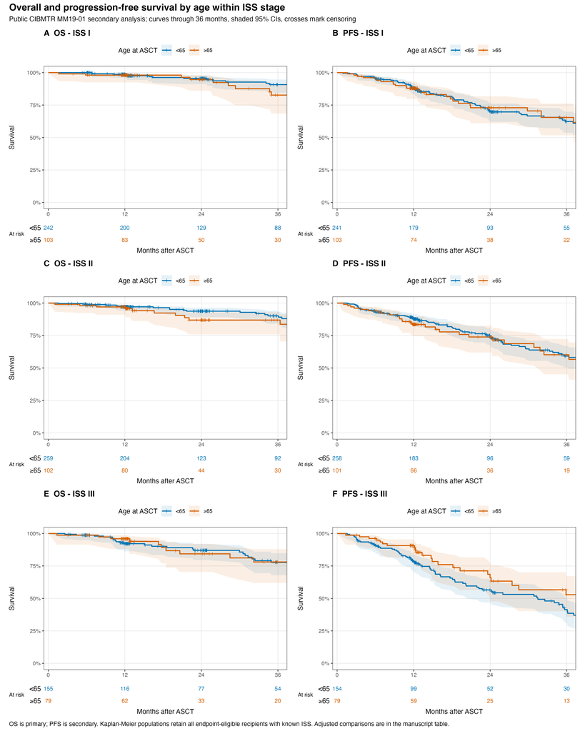

Unadjusted OS (left column) and PFS (right column), with ISS I, II, and III from top to bottom and ages <65 and ≥65. Curves display 0–36 months; numbers at risk are shown at 0, 12, 24, and 36 months. Curves use endpoint-eligible populations, not the smaller complete-case model populations. Shaded bands show 95% CIs; crosses mark censoring. Numerical 24-month CIs are in Table 1. Interpret later estimates cautiously because older risk sets are small.

**Show code for this figure**

```r
# ---- kaplan-meier-figure ----
# Compact six-panel supplemental KM figure with uncertainty, censor marks, and risk tables.
curve_data <- bind_rows(km_curves); censor_data <- bind_rows(km_censors); risk_data <- bind_rows(km_risks)
# Concatenated Symbol-font plotmath gives a compact ≥65 label on native PDF and PNG.
# Avoid a binary >= operator because plotmath inserts mathematical spacing.
for (plot_data in c('curve_data', 'censor_data', 'risk_data')) {
  plot_frame <- get(plot_data)
  plot_frame$age_group <- factor(plot_frame$age_group, levels = age_labels)
  assign(plot_data, plot_frame)
}
plot_age_colors <- setNames(unname(age_colors), age_labels)
plot_age_labels <- expression('<65', paste(symbol('\263'), '65'))
plot_times <- c(0, 12, 24, 36)
plot_limits <- c(0, 36)
plot_expansion <- expansion(mult = c(.02, .04))
panels <- list()
for (s in levels(analytic$ISS)) for (ep in names(endpoints)) {
  cd <- curve_data |> filter(ISS == s, endpoint == ep)
  cc <- censor_data |> filter(ISS == s, endpoint == ep, time <= 36)
  rd <- risk_data |> filter(ISS == s, endpoint == ep)
  letter <- LETTERS[(match(s, levels(analytic$ISS)) - 1L) * 2L + match(ep, names(endpoints))]
  p <- ggplot(cd, aes(time, survival, color = age_group, fill = age_group)) +
    geom_ribbon(data = cd |> filter(is.finite(lower), is.finite(upper)), aes(ymin = lower, ymax = upper), alpha = .10, color = NA) +
    geom_step(linewidth = .7) + geom_point(data = cc, shape = 3, size = 1.3, stroke = .4) +
    scale_color_manual(values = plot_age_colors, labels = plot_age_labels) + scale_fill_manual(values = plot_age_colors, labels = plot_age_labels) +
    coord_cartesian(xlim = plot_limits, ylim = c(0, 1)) +
    scale_x_continuous(breaks = plot_times, expand = plot_expansion) +
    scale_y_continuous(labels = function(x) paste0(round(100*x), '%')) +
    labs(title = paste0(letter, '  ', ep, ' - ISS ', s), x = NULL, y = 'Survival', color = 'Age at ASCT', fill = 'Age at ASCT') +
    theme_bw(base_size = 10) + theme(legend.position = 'top', plot.title = element_text(face = 'bold'), panel.grid.minor = element_blank())
  risk <- ggplot(rd, aes(month, factor(age_group, levels = rev(age_labels)), label = n_risk, color = age_group)) +
    geom_text(size = 3.0) + scale_color_manual(values = plot_age_colors, guide = 'none') +
    scale_y_discrete(breaks = age_labels, labels = plot_age_labels) +
    coord_cartesian(xlim = plot_limits) +
    scale_x_continuous(breaks = plot_times, expand = plot_expansion) +
    labs(x = 'Months after ASCT', y = 'At risk') + theme_void(base_size = 10) +
    theme(axis.text.x = element_blank(), axis.ticks.x = element_blank(),
          axis.text.y = element_text(), axis.title.x = element_text(),
          axis.title.y = element_text(angle = 0, size = 8, margin = margin(r = 4)), plot.margin = margin(0, 8, 5, 8))
  # Identical data coordinates, panel ranges and patchwork columns place risk counts
  # directly below the main-plot tick times; validation does not alter observations.
  main_build <- ggplot_build(p); risk_build <- ggplot_build(risk)
  main_range <- main_build$layout$panel_params[[1]]$x.range
  risk_range <- risk_build$layout$panel_params[[1]]$x.range
  stopifnot(identical(as.numeric(main_range), as.numeric(risk_range)),
            identical(sort(unique(as.numeric(risk_build$data[[1]]$x))), plot_times),
            identical(as.numeric(risk_build$data[[1]]$x), as.numeric(rd$month)),
            identical(as.character(risk_build$data[[1]]$label), as.character(rd$n_risk)))
  main_positions <- (plot_times - main_range[1]) / diff(main_range)
  risk_positions <- (risk_build$data[[1]]$x - risk_range[1]) / diff(risk_range)
  stopifnot(all(abs(risk_positions - main_positions[match(rd$month, plot_times)]) < 1e-12))
  panel <- p / risk + plot_layout(heights = c(4, .75))
  panel_gtable <- patchwork::patchworkGrob(panel)
  panel_layout <- panel_gtable$layout[panel_gtable$layout$name %in% c('panel-1', 'panel-2'), ]
  stopifnot(nrow(panel_layout) == 2L, length(unique(panel_layout$l)) == 1L,
            length(unique(panel_layout$r)) == 1L)
  panels[[paste(ep, s)]] <- panel
}
grid <- wrap_plots(panels, ncol = 2) + plot_annotation(
  title = 'Overall and progression-free survival by age within ISS stage',
  subtitle = 'Public CIBMTR MM19-01 secondary analysis; curves through 36 months, shaded 95% CIs, crosses mark censoring',
  caption = 'OS is primary; PFS is secondary. Kaplan-Meier populations retain all endpoint-eligible recipients with known ISS. Adjusted comparisons are in the manuscript table.',
  theme = theme(plot.title = element_text(size = 14, face = 'bold'), plot.subtitle = element_text(size = 10),
                plot.caption = element_text(size = 9, hjust = 0)))
ggsave(file.path(out_dir, 'figures', 'supplemental_kaplan_meier.pdf'), grid, device = pdf, width = 12, height = 15, limitsize = FALSE)
ggsave(file.path(out_dir, 'figures', 'supplemental_kaplan_meier.png'), grid, width = 12, height = 15, dpi = 300, bg = 'white', limitsize = FALSE)
# ---- display-supplementary-figure-1 ----
knitr::include_graphics(file.path(run_dir,publication_manifest$figures[[1]]$path),rel_path=FALSE)
```

# 5 Computational environment

| Software | Version |
| --- | --- |
| R | 4.6.1 |
| haven | 2.5.5 |
| dplyr | 1.2.1 |
| survival | 3.8.6 |
| ggplot2 | 4.0.3 |
| patchwork | 1.3.2 |
| jsonlite | 2.0.0 |
| survRM2 | 1.0.4 |
| rmarkdown | 2.32 |
| knitr | 1.51 |
| gt | 1.3.0 |
| htmltools | 0.5.9 |
| digest | 0.6.39 |
| highr | 0.12 |